# InceptionV3Model_PlantSeedClassification_GroupD

**Author:** Rupa Ghosh  
**About this File:** This is part of Group D Data mining project for Plant Seedling Classification.  
**Overview of the File:**

1. Starts with mounting the Shared folder where the Train and Test Data is stored.
2. The Images are located in the Train Folder in 12 different folders based on the seedling type.
3. Preprocessing included checking the number of images by seedling type. A bar chart showing this distribution is included.
4. We also look at the variation of the sizes of the image files. This dataframe called images sizes was alos stored as a pickle file for easy load and usage.
5. The Images are first read and a Numpy array is created in grayscale to prepresent the images in 45 by 45 size. This process took a long time to complete, so this data was saved in a picke file and was loaded and used for subsequent processing.
6. PCA and TSNE is done. TSNE viusally shows various clusters.
7. The next section is to do models with InceptionV3.
8. A GridSearch with no cross validation was also done. I initially tried cross validation but the environment kept crashing. For some reason it did not use GPU correctly.
9. This model was then used to predict in the test part of the training data. The accuracy matrix is also shown.

```python
from google.colab import drive
drive.mount('/content/drive', force_remount=True)
```

```python
%matplotlib inline
import os
import matplotlib
import matplotlib.pyplot as plt
from matplotlib.offsetbox import OffsetImage, AnnotationBbox
import cv2
import numpy as np
from glob import glob
import matplotlib.cm as cm
from sklearn.decomposition import PCA
from sklearn.manifold import TSNE
from sklearn.preprocessing import StandardScaler
import pickle
```

```python
BASE_DATA_FOLDER = '/content/drive/Shared drives/Data Mining Project/Rupa_Data/'
TRAin_DATA_FOLDER = os.path.join(BASE_DATA_FOLDER, "train")
```

The next few sections contan utility functions to create masks, create segmentsfor the images

```python
def create_mask_for_plant(image):
    image_hsv = cv2.cvtColor(image, cv2.COLOR_BGR2HSV)

    sensitivity = 35
    lower_hsv = np.array([60 - sensitivity, 100, 50])
    upper_hsv = np.array([60 + sensitivity, 255, 255])

    mask = cv2.inRange(image_hsv, lower_hsv, upper_hsv)
    kernel = cv2.getStructuringElement(cv2.MORPH_ELLIPSE, (11,11))
    mask = cv2.morphologyEx(mask, cv2.MORPH_CLOSE, kernel)

    return mask

def segment_plant(image):
    mask = create_mask_for_plant(image)
    output = cv2.bitwise_and(image, image, mask = mask)
    return output
```

```python
## This function is to create  a scatter plot with the actual images, This is used for TSNE plots later in the file.

def visualize_scatter_with_images(X_2d_data, images, figsize=(45,45), image_zoom=1):
    fig, ax = plt.subplots(figsize=figsize)
    artists = []
    for xy, i in zip(X_2d_data, images):
        x0, y0 = xy
        img = OffsetImage(i, zoom=image_zoom)
        ab = AnnotationBbox(img, (x0, y0), xycoords='data', frameon=False)
        artists.append(ax.add_artist(ab))
    ax.update_datalim(X_2d_data)
    ax.autoscale()
    plt.show()
```

```python
## this function creates scatter plots with dots
def visualize_scatter(data_2d, label_ids, figsize=(20,20)):
    plt.figure(figsize=figsize)
    plt.grid()


    nb_classes = len(np.unique(label_ids))

    for label_id in np.unique(label_ids):
        plt.scatter(data_2d[np.where(label_ids == label_id), 0],
                    data_2d[np.where(label_ids == label_id), 1],
                    marker='o',
                    color= plt.cm.Set1(label_id / float(nb_classes)),
                    linewidth='1',
                    alpha=0.8,
                    label=id_to_label_dict[label_id])
    plt.legend(loc='best')
```

```python
## This is a very important section that creates numpy arrays of the images with the labels.
## This takes over 1 hour to run for the 4700 images that we have .  I have executed this a few times and I have saved a pickle file of the
## numpy array as a pickle file that I load and use.
##Commenting this out becasue I will load from the pickle files previously saved

#images = []
#labels = []
images_path = []

#for class_folder_name in os.listdir(TRAin_DATA_FOLDER):
#    class_folder_path = os.path.join(TRAin_DATA_FOLDER, class_folder_name)
#    for image_path in glob(os.path.join(class_folder_path, "*.png")):
#        image = cv2.imread(image_path, cv2.IMREAD_COLOR)

#        image = cv2.resize(image, (150, 150))
#        image = segment_plant(image)
#        image = cv2.cvtColor(image, cv2.COLOR_BGR2GRAY)
#        image = cv2.resize(image, (45,45))

#        image = image.flatten()

#        images.append(image)
#        labels.append(class_folder_name)
#        images_path.append(image_path)

#images = np.array(images)
#labels = np.array(labels)
```

```python
# Save a dictionary into a pickle file.
import pickle

#pickle.dump( images, open( "/content/drive/Shared drives/Data Mining Project/Rupa_Data/rg_save_images.p", "wb" ) )
#pickle.dump( labels, open( "/content/drive/Shared drives/Data Mining Project/Rupa_Data/rg_save_labels.p", "wb" ) )
```

```python
## Loading the pickle files for images and the labels
images= pickle.load( open( "/content/drive/Shared drives/Data Mining Project/Rupa_Data/rg_save_images.p", "rb" ) )
labels = pickle.load( open( "/content/drive/Shared drives/Data Mining Project/Rupa_Data/rg_save_labels.p", "rb" ) )
```

```python
label_to_id_dict = {v:i for i,v in enumerate(np.unique(labels))}
id_to_label_dict = {v: k for k, v in label_to_id_dict.items()}
id_to_label_dict
```

```
{0: 'Black-grass',
 1: 'Charlock',
 2: 'Cleavers',
 3: 'Common Chickweed',
 4: 'Common wheat',
 5: 'Fat Hen',
 6: 'Loose Silky-bent',
 7: 'Maize',
 8: 'Scentless Mayweed',
 9: 'Shepherds Purse',
 10: 'Small-flowered Cranesbill',
 11: 'Sugar beet'}
```

```python
from subprocess import check_output

classes = check_output(["ls", TRAin_DATA_FOLDER]).decode("utf8").strip().split("\n")
```

```python
classes
```

```
['Black-grass',
 'Charlock',
 'Cleavers',
 'Common Chickweed',
 'Common wheat',
 'Fat Hen',
 'Loose Silky-bent',
 'Maize',
 'Scentless Mayweed',
 'Shepherds Purse',
 'Small-flowered Cranesbill',
 'Sugar beet']
```

```python
dir_list = []
for c in classes:
    files = check_output(["ls", "/content/drive/Shared drives/Data Mining Project/Rupa_Data/train/%s" % c]).decode("utf8").strip().split("\n")
    dir_list.append(files)
    files = check_output(["ls", "-l", "/content/drive/Shared drives/Data Mining Project/Rupa_Data/train/%s" % c]).decode("utf8").strip().split("\n")
```

```python
import pandas as pd
df = pd.DataFrame({"n_images": [len(x) for x in dir_list]}, index=classes)
index = df.index
number_of_rows = len(index)
print(number_of_rows)
```

```
12
```

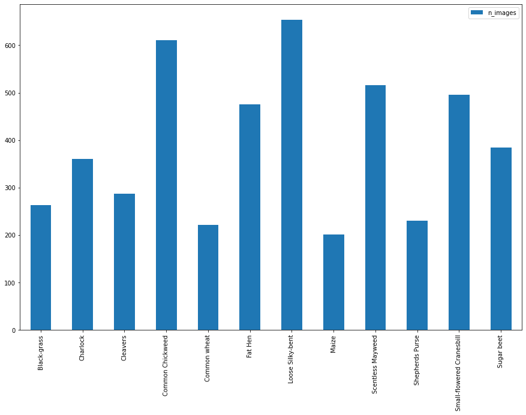

```python
df.plot(kind="bar", figsize=(15,10))
```

```python
label_ids = np.array([label_to_id_dict[x] for x in labels])
```

```python
images_scaled = StandardScaler().fit_transform(images)
```

```python
images_scaled.shape
```

```
(4700, 2025)
```

```python
label_ids.shape
```

```
(4700,)
```

```python
## Lets look at the sizes of the images
```

```python
## rhis takes over 40 mins.  I have saved a pickle file that I will load from
#images_list = []
#im_class = []
#im_height = []
#im_width = []
#for c, files in zip(classes, dir_list):
#    for img in files:
#        im = Image.open("/content/drive/Shared drives/Data Mining Project/Rupa_Data/train/%s/%s" % (c, img))
#        images_list.append(img)
#        im_class.append(c)
#        im_height.append(im.height)
#        im_width.append(im.width)

#df_all = pd.DataFrame({"class": im_class, "height": im_height, "width": im_width}, index=images_list)
```

```python
#import pickle
#pickle.dump( df_all, open( "/content/drive/Shared drives/Data Mining Project/Rupa_Data/rg_save_image_sizes.p", "wb" ) )
```

```python
df_all_imageSizes = pickle.load( open( "/content/drive/Shared drives/Data Mining Project/Rupa_Data/rg_save_image_sizes.p", "rb" ) )
```

```python
df_all_imageSizes.describe()
```

|  | height | width |
| --- | --- | --- |
| count | 4700.000000 | 4700.000000 |
| mean | 371.568723 | 372.312340 |
| std | 319.758475 | 324.414833 |
| min | 49.000000 | 49.000000 |
| 25% | 140.000000 | 140.000000 |
| 50% | 266.500000 | 266.500000 |
| 75% | 509.000000 | 509.000000 |
| max | 3457.000000 | 3991.000000 |

## PCA

```python
pca = PCA(n_components=180) ## was 180
pca_result = pca.fit_transform(images_scaled)
```

```python
pca_result.shape
```

```
(4700, 180)
```

## t-SNE after PCA

```python
tsne = TSNE(n_components=2, perplexity=40.0)
```

```python
tsne_result = tsne.fit_transform(pca_result)
```

```python
tsne_result_scaled = StandardScaler().fit_transform(tsne_result)
```

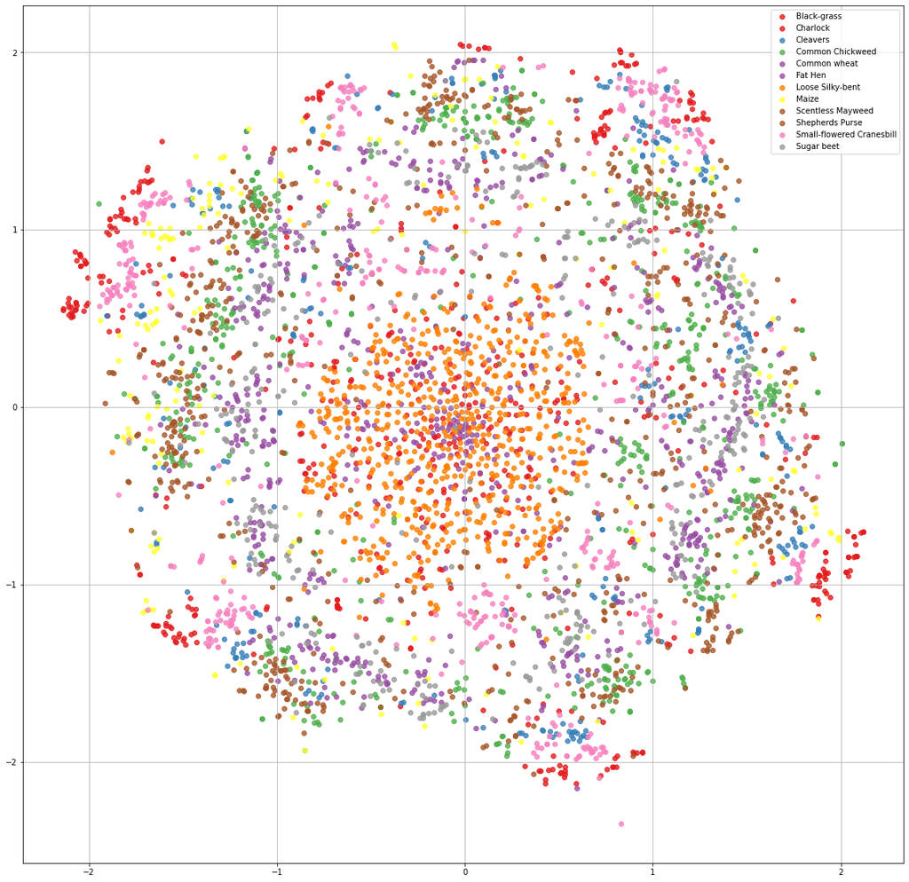

```python
visualize_scatter(tsne_result_scaled, label_ids)
```

```python
#visualize_scatter_with_images(tsne_result_scaled, images = [np.reshape(i, (45,45)) for i in images], image_zoom=0.7)
```

## 3D t-SNE with animation

```python
tsne = TSNE(n_components=3)
tsne_result = tsne.fit_transform(pca_result)
tsne_result_scaled = StandardScaler().fit_transform(tsne_result)
```

```python
from mpl_toolkits.mplot3d import Axes3D
from matplotlib import animation
```

[output not shown]

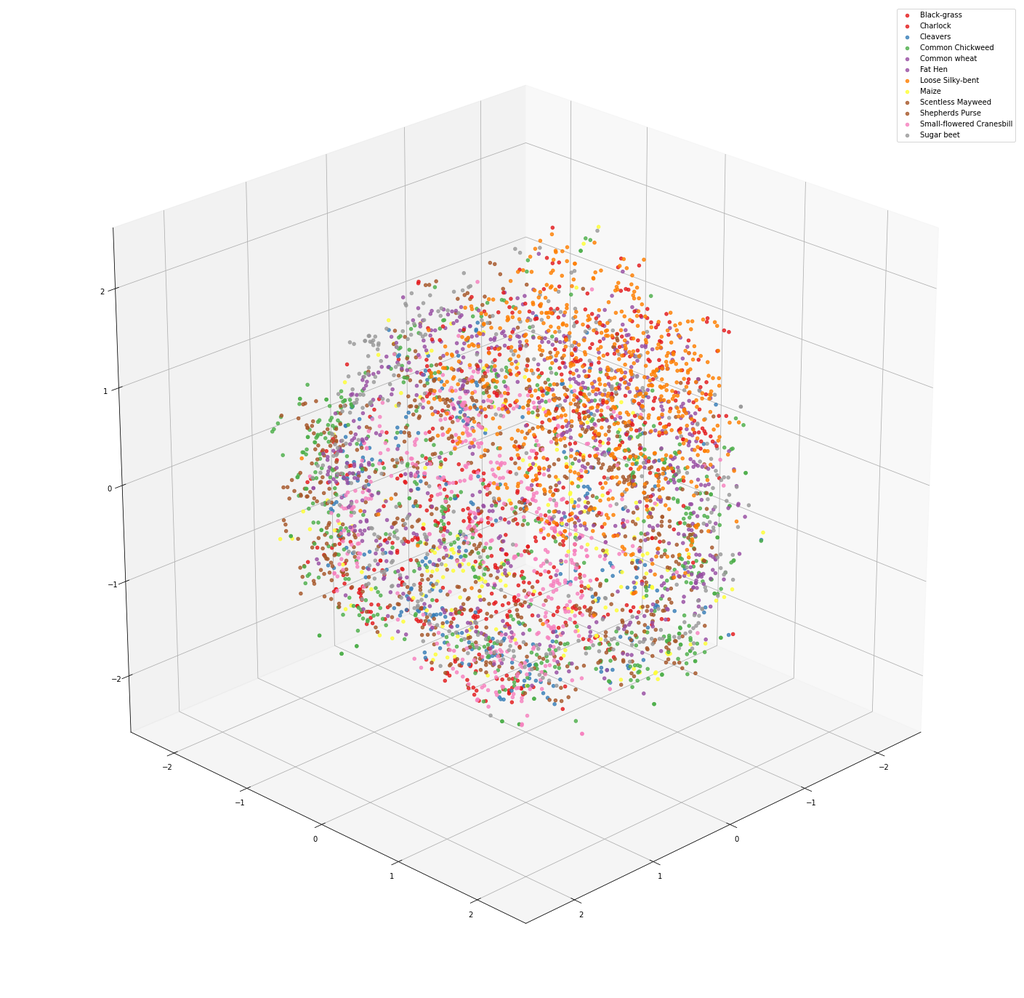

```python
fig = plt.figure(figsize=(25,25))
ax = fig.add_subplot(111,projection='3d')

plt.grid()

nb_classes = len(np.unique(label_ids))

for label_id in np.unique(label_ids):
    ax.scatter(tsne_result_scaled[np.where(label_ids == label_id), 0],
                tsne_result_scaled[np.where(label_ids == label_id), 1],
                tsne_result_scaled[np.where(label_ids == label_id), 2],
                alpha=0.8,
                color= plt.cm.Set1(label_id / float(nb_classes)),
                marker='o',
                label=id_to_label_dict[label_id])
ax.legend(loc='best')
ax.view_init(25, 45)
ax.set_xlim(-2.5, 2.5)
ax.set_ylim(-2.5, 2.5)
ax.set_zlim(-2.5, 2.5)
```

```python
anim = animation.FuncAnimation(fig, lambda frame_number: ax.view_init(30, 4 * frame_number), interval=75, frames=90)
```

```python
plot_3d_animation_filename = 'animation.gif'
#anim.save(plot_3d_animation_filename, writer='imagemagick')
```

```python
#import io
#import base64
#from IPython.display import HTML

#video = io.open(plot_3d_animation_filename, 'r+b').read()
# HTML(data='''<img src="data:…" type="gif" />'''.format(base64.b64encode(video).decode('ascii')))
```

With this last step we would get a neat little 3D scatter plot animation. I commented it, because the size of the gif can take up to 30MB and it slows down the whole notebook unfortunately. If you would like to try it out, just uncomment it and run the last cell. Or of course you can view it with any program because it is saved as `animation.gif`

```python
from keras.applications.inception_v3 import InceptionV3
from keras.applications import inception_v3
from keras.applications.resnet50 import ResNet50
from keras.applications import resnet50
from keras.preprocessing.image import load_img
from keras.preprocessing.image import img_to_array

from sklearn.preprocessing import LabelEncoder
#from sklearn.preprocessing import LabelBinarizer
from sklearn.model_selection import GridSearchCV
from sklearn.model_selection import train_test_split
from sklearn.metrics import classification_report
from sklearn.metrics import accuracy_score
from sklearn.metrics import confusion_matrix
from sklearn.linear_model import LogisticRegression
from sklearn.decomposition import PCA
from sklearn.manifold import TSNE

import numpy as np
import glob

import matplotlib.pyplot as plt
%matplotlib inline
```

```python
TRAin_DATA_FOLDER
```

```
'/content/drive/Shared drives/Data Mining Project/Rupa_Data/train'
```

```python
#images_path = glob.glob("TRAin_DATA_FOLDER/*")
#images_path ## printing images path for debugging
```

```python
##Using label encoder for the seedling labels
le = LabelEncoder()
#lb = LabelBinarizer()
labels2 = le.fit_transform(labels)
#labels = lb.fit_transform(labels)

print(labels2.shape)
```

```
(4700,)
```

```python
label_ids.shape
```

```
(4700,)
```

```python
def extract_features(model, preprocess):
    features = []
    BS = 128
    for i in np.arange(0, len(images_path), BS):
        pb = images_path[i:i+BS]
        xb = []

        for xx in pb:
            img = load_img(xx, target_size=(200, 200))
            img = img_to_array(img)
            img = np.expand_dims(img, axis=0)
            img = preprocess(img)
            xb.append(img)

        xb = np.vstack(xb)
        feature = model.predict(xb, batch_size=BS)
        feature = np.reshape(feature, (feature.shape[0], -1))

        features.append(feature)

    features = np.vstack(features)
    print(model.summary())
    print(features.shape)
    print(features.nbytes / (1024000))

    return features
```

```python
## Not running the model I will load it from pickle
#model = InceptionV3(weights="imagenet", include_top=False)
#v3_features = extract_features(model, inception_v3.preprocess_input)
```

```python
#pickle.dump( model, open( "/content/drive/Shared drives/Data Mining Project/Rupa_Data/rg_InceptionV3_model.p", "wb" ) )
#pickle.dump( v3_features, open( "/content/drive/Shared drives/Data Mining Project/Rupa_Data/rg_InceptionV3_features.p", "wb" ) )
```

```python
float(len(np.unique(labels)))
```

```
12.0
```

```python
# Load V3_features from pickle file
import pickle
v3_features =  pickle.load( open( "/content/drive/Shared drives/Data Mining Project/Rupa_Data/rg_InceptionV3_features.p", "rb" ) )
```

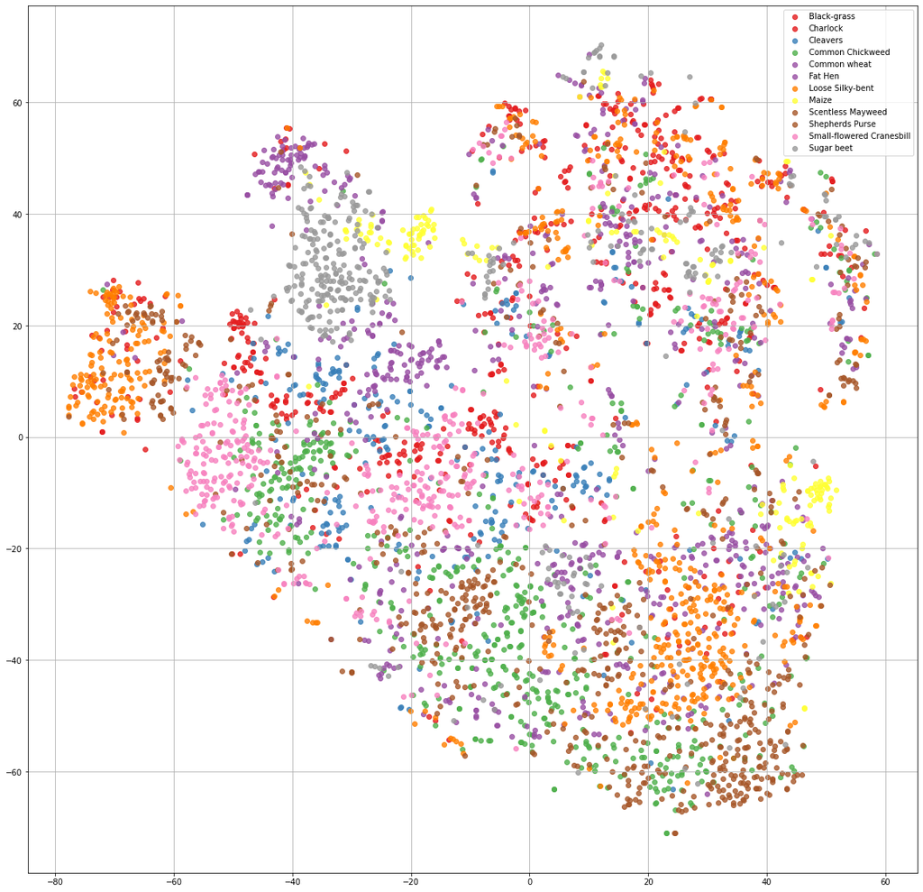

```python
#pca = PCA(50)
#tsne = TSNE(2)
pca = PCA(50)
tsne = TSNE(2)
feature_pca = pca.fit_transform(v3_features)
feature_tsne = tsne.fit_transform(feature_pca)

visualize_scatter(feature_tsne, label_ids)
```

```python
#model = ResNet50(weights="imagenet", include_top=False)
#res_features = extract_features(model, resnet50.preprocess_input)
```

```python
#Save the resnet features in a pickle file
#pickle.dump(res_features, open( "/content/drive/Shared drives/Data Mining Project/Rupa_Data/rg_ResNet50_features.p", "wb" ) )
```

```python
## Load resnet features from pickle file

# Load res_features from pickle file
res_features =  pickle.load( open( "/content/drive/Shared drives/Data Mining Project/Rupa_Data/rg_ResNet50_features.p", "rb" ) )
```

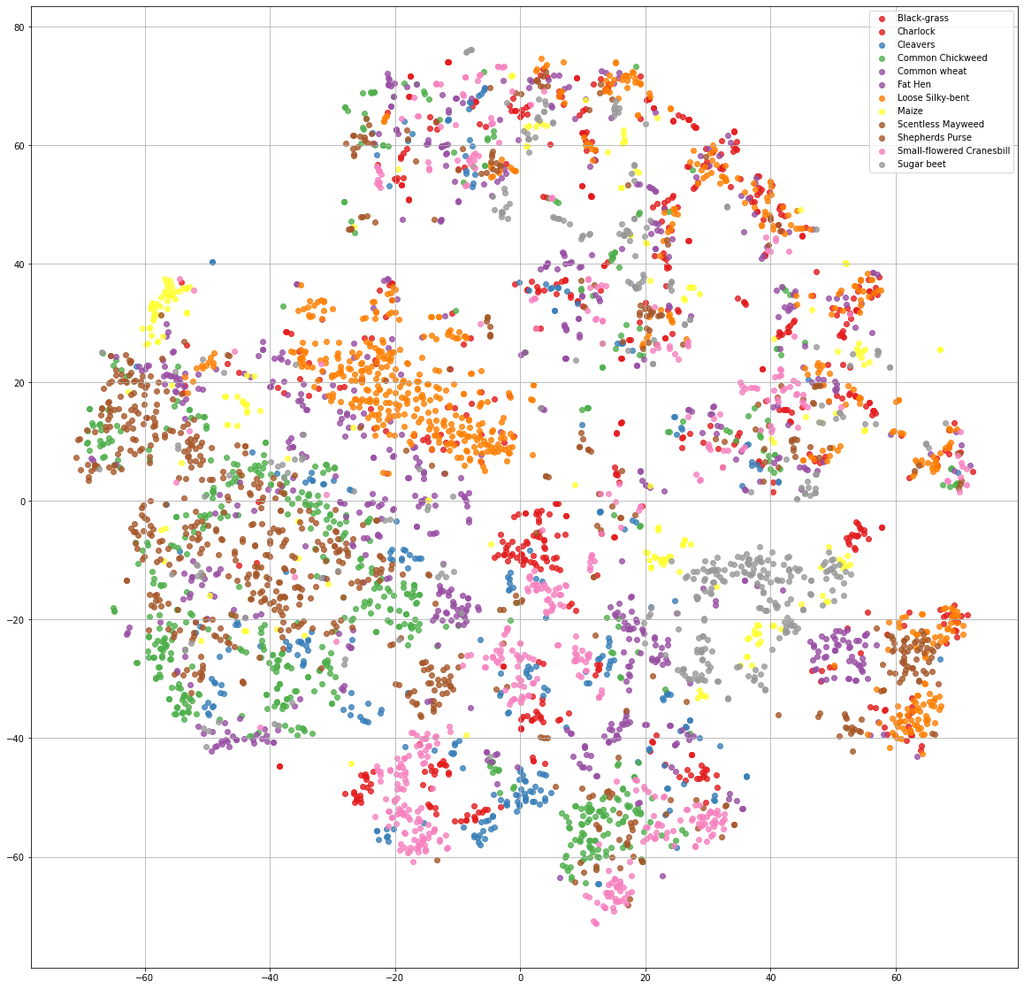

```python
feature_pca = pca.fit_transform(res_features)
feature_tsne = tsne.fit_transform(feature_pca)
visualize_scatter(feature_tsne, label_ids)
```

```python
params = {"C": [0.0001, 0.001, 0.01, 0.1, 1.0], "solver": ["liblinear", "lbfgs"],
          "class_weight": [None, "balanced"]}
cv = [(slice(None), slice(None))]
model = GridSearchCV(LogisticRegression(), params, cv=cv, n_jobs=-1, verbose=3)
```

```python
Xtr, Xval, ytr, yval = train_test_split(v3_features, labels, test_size=200, random_state=42)
## I am commenting this out because this takes 2 hours to run. So I have saved the model in a pickle.
## the model will be loaded from pickle file.
#model.fit(Xtr, ytr)
```

```python
#Save the grid search model in a pickle file
#pickle.dump(model, open( "/content/drive/Shared drives/Data Mining Project/Rupa_Data/rg_gridSearchModel_1.p", "wb" ) )
```

```python
## Load the model from saved pickle file
```

```python
gs_model= pickle.load( open( "/content/drive/Shared drives/Data Mining Project/Rupa_Data/rg_gridSearchModel_1.p", "rb" ) )
```

```python
# failed after an hour.This is the ResNet model.
#Xtr, Xval, ytr, yval = train_test_split(res_features, labels, test_size=200, random_state=42)

#model.fit(Xtr, ytr)
```

```python
gs_model.best_params_
```

```
{'C': 0.01, 'class_weight': None, 'solver': 'liblinear'}
```

```python
predictions = gs_model.predict(Xval)
```

```python
#np.unique((labels))
```

```python
print(classification_report(yval, predictions, target_names=np.unique((labels))))
#print(classification_report(yval, predictions, target_names=label_ids))

print("Accuracy: {:.3f}".format(accuracy_score(yval, predictions)))
```

```
                           precision    recall  f1-score   support

              Black-grass       0.78      0.54      0.64        13
                 Charlock       0.84      0.94      0.89        17
                 Cleavers       0.88      0.79      0.83        19
         Common Chickweed       0.86      0.86      0.86        22
             Common wheat       0.89      0.67      0.76        12
                  Fat Hen       0.89      0.94      0.92        18
         Loose Silky-bent       0.75      0.90      0.82        30
                    Maize       0.89      0.73      0.80        11
        Scentless Mayweed       0.87      0.81      0.84        16
          Shepherds Purse       0.25      0.33      0.29         3
Small-flowered Cranesbill       0.85      0.89      0.87        19
               Sugar beet       0.90      0.95      0.93        20

                 accuracy                           0.83       200
                macro avg       0.80      0.78      0.79       200
             weighted avg       0.84      0.83      0.83       200

Accuracy: 0.835
```

```python
## Now on to testing this on images scraped from Google.
images_for_test = []
#labels = []
test_images_path = []
Test_DATA_FOLDER = '/content/drive/Shared drives/Data Mining Project/Rupa_Data/Test_new'

for class_folder_name in os.listdir(Test_DATA_FOLDER):
    class_folder_path = os.path.join(Test_DATA_FOLDER)
    for test_image_path in glob(os.path.join(class_folder_path, "*.png")):
        test_image = cv2.imread(test_image_path, cv2.IMREAD_COLOR)

        test_image = cv2.resize(test_image, (150, 150))
        test_image = segment_plant(test_image)
        test_image = cv2.cvtColor(test_image, cv2.COLOR_BGR2GRAY)
        test_image = cv2.resize(test_image, (45,45))

        test_image = test_image.flatten()

        images_for_test.append(test_image)
        #labels.append(class_folder_name)
        test_images_path.append(test_image_path)

images_for_test = np.array(images_for_test)
#labels = np.array(labels)
```

```python
# Run the test data through V3 features


def extract_test_features(model, preprocess):
    test_features = []
    BS = 128
    for i in np.arange(0, len(test_images_path), BS):
        pb = test_images_path[i:i+BS]
        xb = []

        for xx in pb:
            img = load_img(xx, target_size=(200, 200))
            img = img_to_array(img)
            img = np.expand_dims(img, axis=0)
            img = preprocess(img)
            xb.append(img)

        xb = np.vstack(xb)
        feature = model.predict(xb, batch_size=BS)
        feature = np.reshape(feature, (feature.shape[0], -1))

        test_features.append(feature)

    test_features = np.vstack(test_features)
    print(model.summary())
    print(test_features.shape)
    print(test_features.nbytes / (1024000))

    return test_features
```

```python
model = InceptionV3(weights="imagenet", include_top=False)
test_v3_features = extract_test_features(model, inception_v3.preprocess_input)
```

[output not shown]

[output cut: 615 more lines]

[output not shown]

```python
test_predictions = gs_model.predict(test_v3_features)
Pred_labels_rupa = np.argmax(gs_model.predict(test_v3_features))
```

```python
print(test_predictions)
```

```
['Scentless Mayweed' 'Maize' 'Small-flowered Cranesbill'
 'Scentless Mayweed' 'Maize' 'Cleavers' 'Shepherds Purse' 'Charlock'
 'Scentless Mayweed' 'Maize' 'Small-flowered Cranesbill'
 'Scentless Mayweed' 'Maize' 'Cleavers' 'Shepherds Purse' 'Charlock'
 'Scentless Mayweed' 'Maize' 'Small-flowered Cranesbill'
 'Scentless Mayweed' 'Maize' 'Cleavers' 'Shepherds Purse' 'Charlock'
 'Scentless Mayweed' 'Maize' 'Small-flowered Cranesbill'
 'Scentless Mayweed' 'Maize' 'Cleavers' 'Shepherds Purse' 'Charlock'
 'Scentless Mayweed' 'Maize' 'Small-flowered Cranesbill'
 'Scentless Mayweed' 'Maize' 'Cleavers' 'Shepherds Purse' 'Charlock'
 'Scentless Mayweed' 'Maize' 'Small-flowered Cranesbill'
 'Scentless Mayweed' 'Maize' 'Cleavers' 'Shepherds Purse' 'Charlock'
 'Scentless Mayweed' 'Maize' 'Small-flowered Cranesbill'
 'Scentless Mayweed' 'Maize' 'Cleavers' 'Shepherds Purse' 'Charlock'
 'Scentless Mayweed' 'Maize' 'Small-flowered Cranesbill'
 'Scentless Mayweed' 'Maize' 'Cleavers' 'Shepherds Purse' 'Charlock'
 'Scentless Mayweed' 'Maize' 'Small-flowered Cranesbill'
 'Scentless Mayweed' 'Maize' 'Cleavers' 'Shepherds Purse' 'Charlock'
 'Scentless Mayweed' 'Maize' 'Small-flowered Cranesbill'
 'Scentless Mayweed' 'Maize' 'Cleavers' 'Shepherds Purse' 'Charlock'
 'Scentless Mayweed' 'Maize' 'Small-flowered Cranesbill'
 'Scentless Mayweed' 'Maize' 'Cleavers' 'Shepherds Purse' 'Charlock'
 'Scentless Mayweed' 'Maize' 'Small-flowered Cranesbill'
 'Scentless Mayweed' 'Maize' 'Cleavers' 'Shepherds Purse' 'Charlock'
 'Scentless Mayweed' 'Maize' 'Small-flowered Cranesbill'
 'Scentless Mayweed' 'Maize' 'Cleavers' 'Shepherds Purse' 'Charlock'
 'Scentless Mayweed' 'Maize' 'Small-flowered Cranesbill'
 'Scentless Mayweed' 'Maize' 'Cleavers' 'Shepherds Purse' 'Charlock'
 'Scentless Mayweed' 'Maize' 'Small-flowered Cranesbill'
 'Scentless Mayweed' 'Maize' 'Cleavers' 'Shepherds Purse' 'Charlock'
 'Scentless Mayweed' 'Maize' 'Small-flowered Cranesbill'
 'Scentless Mayweed' 'Maize' 'Cleavers' 'Shepherds Purse' 'Charlock'
 'Scentless Mayweed' 'Maize' 'Small-flowered Cranesbill'
 'Scentless Mayweed' 'Maize' 'Cleavers' 'Shepherds Purse' 'Charlock'
 'Scentless Mayweed' 'Maize' 'Small-flowered Cranesbill'
 'Scentless Mayweed' 'Maize' 'Cleavers' 'Shepherds Purse' 'Charlock'
 'Scentless Mayweed' 'Maize' 'Small-flowered Cranesbill'
 'Scentless Mayweed' 'Maize' 'Cleavers' 'Shepherds Purse' 'Charlock'
 'Scentless Mayweed' 'Maize' 'Small-flowered Cranesbill'
 'Scentless Mayweed' 'Maize' 'Cleavers' 'Shepherds Purse' 'Charlock']
```